# Accident vasculaire cérébral et ses conséquences

Yesmine Bellalah

29 avril 2016

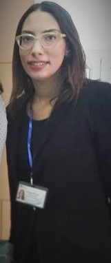

photo

```
            Analyse en composantes principales : Accident vasculaire cérébral et ses conséquences
```

# INTRODUCTION

Aujourd’hui, l’Homme vit dans un monde où règne un rythme très accéléré avec beaucoup de fatigue et efforts physique et mental. C’est pourquoi on entend souvent des cas d’accidents vasculaires-cérébraux qui est une perte soudaine de la fonction du cerveau. Donc on a pris, à partir d’un hôpital des données des patients qui ont récemment subi un accident vasculaire cérébral résultant dans l’hémiplégie ( paralysie d’une ou plusieurs parties du corps d’un seul côté) durable au moins 24 heures. Il s’agit de comparer les 3 outils d’évaluations pour évaluer le rétablissement des patients :

**1-Formulaire de Goteburg**: évaluation de l’hémiplegie en mesurant la fonction motrice, les qualités sensorielles, la mobilité passive.

**2-Formulaire de Bobath** : évaluation des réactions posturales, mouvement volontaire, équilibre et réactions de protections automatiques.

**3-Indice de Barthel et notation de Kenny** : évaluation de la capacité de mener des activités de la vie quotidienne.

# OBJECTIF

Suivre l’état des patients suite à un accident vasculaire cérébral et comparaison des outils d’évaluation pour évaluer leur rétablissement.

# Description de la base

on a une base de données de

-20 patients ( les individus)

-2 varibales qualitatives:

**Sex**

**Side** : Côté du cerveau touché

-12 variables quantitatives :

**Age**

**Lapse**: nombre de semaine

**Arms** : Bras et la fonction motrice de l’épaule

**Legs** : fonction motrice des membres inférieurs

**Hands** : fonction motrice de la main

**Balance**: équilibre

**Sensation**

**JointPain** : Liberté de douleurs articulaires

**jointmotion** : Mouvement de l’articulation passive

**Bobath**

**Barthel**

**Kenny**: score de Kenn

```r
data=read.table(file=file.choose(),header=T,sep=";",row.names = 1)
attach(data)
nrow(data)
```

```
## [1] 20
```

```r
ncol(data)
```

```
## [1] 14
```

```r
str(data)
```

```
## 'data.frame':    20 obs. of  14 variables:
##  $ Sex        : Factor w/ 2 levels "femme","homme": 2 2 1 1 2 1 1 1 1 2 ...
##  $ Side       : Factor w/ 2 levels "droit","gauche": 2 2 2 1 2 1 1 2 2 1 ...
##  $ Age        : int  59 64 66 57 59 67 23 63 76 84 ...
##  $ Lapse      : int  14 2 39 22 41 35 6 12 156 36 ...
##  $ Arms       : int  9 5 36 36 32 22 14 36 20 36 ...
##  $ Legs       : int  30 11 30 20 30 30 30 22 18 20 ...
##  $ Hands      : int  2 0 23 14 6 9 2 21 3 24 ...
##  $ Balance    : int  12 1 14 14 6 14 13 3 9 9 ...
##  $ Sensation  : int  24 6 24 14 24 24 24 24 24 24 ...
##  $ JointPain  : int  24 24 24 24 24 21 24 24 24 24 ...
##  $ JointMotion: int  24 24 24 12 17 24 22 24 24 24 ...
##  $ Bobath     : int  49 17 112 79 51 52 41 148 43 226 ...
##  $ Barthel    : int  90 35 90 85 80 70 70 30 65 70 ...
##  $ Kenny      : num  22 11 23 22.2 20.4 19.7 17.9 4.9 18.4 19.1 ...
```

```r
head(data)
```

```
##           Sex   Side Age Lapse Arms Legs Hands Balance Sensation JointPain
## barry   homme gauche  59    14    9   30     2      12        24        24
## padriac homme gauche  64     2    5   11     0       1         6        24
## Narelle femme gauche  66    39   36   30    23      14        24        24
## Jaklin  femme  droit  57    22   36   20    14      14        14        24
## rachael homme gauche  59    41   32   30     6       6        24        24
## sabelle femme  droit  67    35   22   30     9      14        24        21
##         JointMotion Bobath Barthel Kenny
## barry            24     49      90  22.0
## padriac          24     17      35  11.0
## Narelle          24    112      90  23.0
## Jaklin           12     79      85  22.2
## rachael          17     51      80  20.4
## sabelle          24     52      70  19.7
```

# Analyse en composantes principales : ( ACP)

Vu la nature de la base , on emploie la méthode d’analyse en composantes principales en considérant les 2 premières variables comme varibales qualitatives supplémentaires et le reste des vavribles comme des variables actives

# 1)- Les valeurs propres ( le scree plot)

```r
library(FactoMineR)
res.pca=PCA(data,quali.sup =1:2,graph =F)
res.pca$eig
```

```
##         eigenvalue percentage of variance
## comp 1  4.87058759            40.58822993
## comp 2  2.06115686            17.17630718
## comp 3  1.32054320            11.00452668
## comp 4  1.25224663            10.43538855
## comp 5  0.97823264             8.15193871
## comp 6  0.66474704             5.53955868
## comp 7  0.33081841             2.75682005
## comp 8  0.24170683             2.01422361
## comp 9  0.14837585             1.23646539
## comp 10 0.09124176             0.76034804
## comp 11 0.03024820             0.25206830
## comp 12 0.01009499             0.08412489
##         cumulative percentage of variance
## comp 1                           40.58823
## comp 2                           57.76454
## comp 3                           68.76906
## comp 4                           79.20445
## comp 5                           87.35639
## comp 6                           92.89595
## comp 7                           95.65277
## comp 8                           97.66699
## comp 9                           98.90346
## comp 10                          99.66381
## comp 11                          99.91588
## comp 12                         100.00000
```

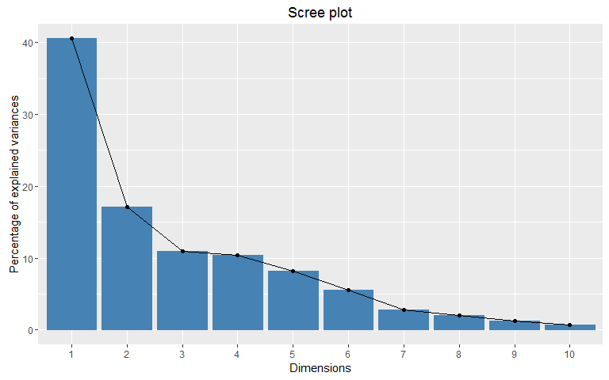

```r
library(ggplot2)
library(grid)
library(factoextra)
fviz_screeplot(res.pca)
```

# 2)- Cercle de corrélation

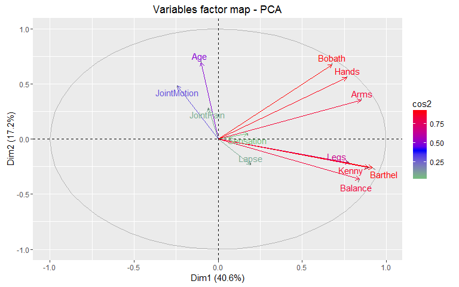

```r
fviz_pca_var(res.pca,col.var="cos2")+scale_color_gradient2(low="green",mid="blue",high="red",midpoint=0.4)
```

# 3)-Matrice de corrélation avec les axes

```r
res.pca$var$cor[,1:2]
```

```
##                   Dim.1       Dim.2
## Age         -0.10004580  0.69457079
## Lapse        0.19353881 -0.23343599
## Arms         0.85053615  0.35407697
## Legs         0.77917389 -0.21437328
## Hands        0.76508106  0.55848533
## Balance      0.84078194 -0.36274136
## Sensation    0.17566595  0.05044984
## JointPain   -0.06024594  0.28315145
## JointMotion -0.24536789  0.48399660
## Bobath       0.67733861  0.67587994
## Barthel      0.91875416 -0.26108629
## Kenny        0.89595974 -0.25974982
```

La matrice de corrélations montre que arms , legs , balance ,Barbeth , kenny sont très bien corrolées avec le 1er axe , et que les variables age et Bobath sont bien corrélées avec le second axe.

# 4)-Matrice de corrélation entre les variables

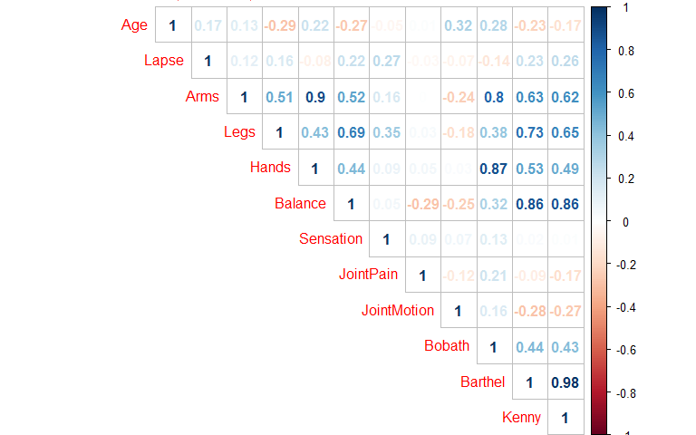

```r
R <- cor(data[,-c(1,2)])
library(corrplot)
corrplot(R,method="number",type="upper")
```

# 5)-contribution des variables

```r
res.pca$var$contrib[,1:2]
```

```
##                   Dim.1      Dim.2
## Age          0.20550213 23.4057193
## Lapse        0.76905034  2.6437755
## Arms        14.85265866  6.0825307
## Legs        12.46486067  2.2296169
## Hands       12.01803710 15.1325630
## Balance     14.51394233  6.3838565
## Sensation    0.63356884  0.1234834
## JointPain    0.07452024  3.8897935
## JointMotion  1.23610140 11.3651082
## Bobath       9.41955320 22.1629758
## Barthel     17.33074688  3.3071743
## Kenny       16.48145821  3.2734029
```

**sur le 1er axe :**

le 1er axe est formé principalement par le variable d’évaluation Barthel(17.33%) et kenny (16.48 %), Arms(14.85%) , Balance (14.51%) , Legs(12.46 %) , Hands (12.02 %) .. Donc le premier axe est l’axe qui nous renseigne sur la fonction motrice des membres inférieurs , des bras et de l’épaule , sur l’équilibre et les relations de protection automatiques et sur la capacité de mener des acitivités de la vie quotidienne. On peut appeler cet axe l’axe de la fonctionnalité du corps aprés accident vasculaire cérébral ou l’axe des tests d’évaluation de rétablissement.

```r
rev(sort(round(res.pca$var$contrib[,1],digits = 2)))
```

```
##     Barthel       Kenny        Arms     Balance        Legs       Hands
##       17.33       16.48       14.85       14.51       12.46       12.02
##      Bobath JointMotion       Lapse   Sensation         Age   JointPain
##        9.42        1.24        0.77        0.63        0.21        0.07
```

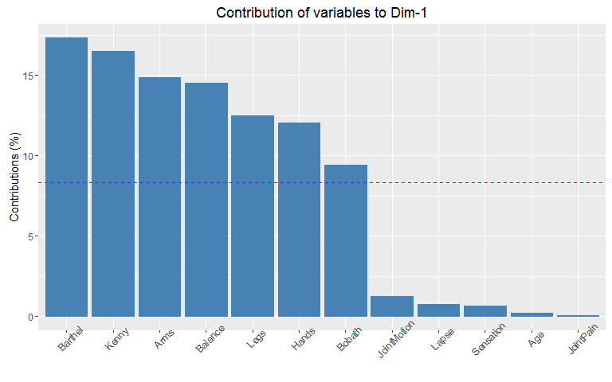

```r
fviz_pca_contrib(res.pca, choice = "var", axes = 1)
```

**sur le 2ème axe:**

le 2ème axe est principalement formé par la variable “age” (23.41%) , “Bobath” (22.16%) , “Hands”(15.13%) et “JoinMotion” (11.37%) . cet axe lie l’age avec le test d’évalution du mouvement volontaire qui englobe naturellement la foncion motrice des mains et le mouvement de l’articulation passive . C’est l’axe de l’age.

```r
rev(sort(round(res.pca$var$contrib[,2],digits = 2)))
```

```
##         Age      Bobath       Hands JointMotion     Balance        Arms
##       23.41       22.16       15.13       11.37        6.38        6.08
##   JointPain     Barthel       Kenny       Lapse        Legs   Sensation
##        3.89        3.31        3.27        2.64        2.23        0.12
```

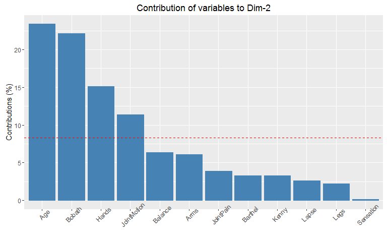

```r
fviz_pca_contrib(res.pca, choice = "var", axes = 2)
```

# 6)- Représentation des patients ( individus)

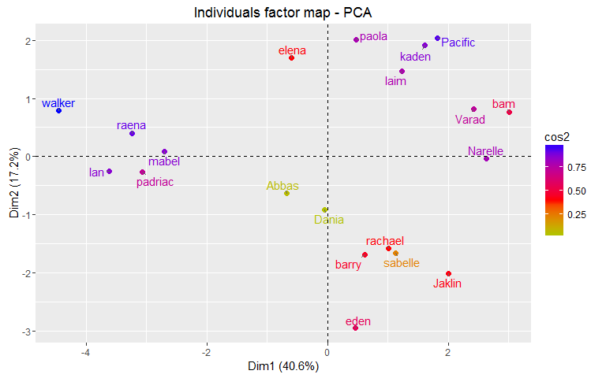

```r
fviz_pca_ind(res.pca,geom=c("point","text"),col.ind="cos2")+scale_color_gradient2(low='green',mid='red',high='blue',midpoint=0.4)
```

D’après le graphe des individus, on remarque que quelques patients présentent une particularité par rapport aux autres patients

-Une meilleure représentation qui met en evidence la 1ère variable qualitative supplémentaire : sex

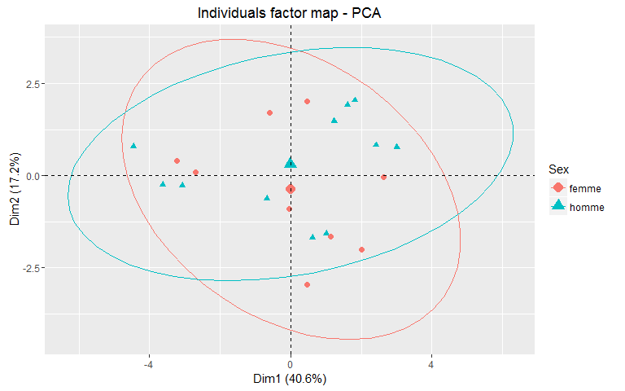

```r
fviz_pca_ind(res.pca, habillage=1,label=T,addEllipses=TRUE, ellipse.level=0.95, alpha.ind=0.5)+theme_gray()
```

On remarque que les femmes ne diffèrent pas beaucoup des hommes , on ne peut faire une classification par sexe .

-une autre qui met en evidence la 2ème varible quali.sup : Side

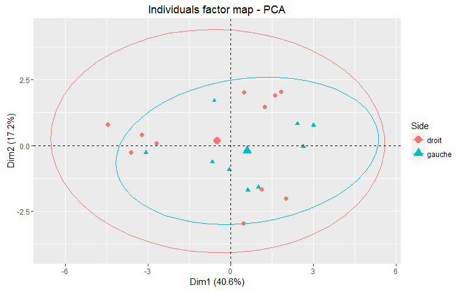

```r
fviz_pca_ind(res.pca, habillage=2,label=T,addEllipses=TRUE, ellipse.level=0.95, alpha.ind=0.5)+theme_gray()
```

# 7)-les ellipses de confiance : Un graphique qui résume tout …

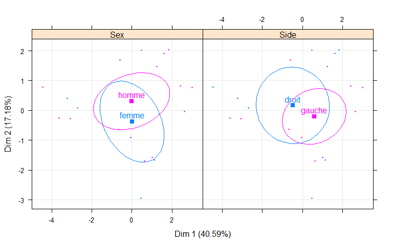

```r
plotellipses(res.pca)
```

# 8)-contribution des patients

**sur le premier axe :**

Les patients qui contribuent le plus à la formation de premier axe sont Walker(20.41), Ian (13.46) , Raena (10.75) ,padric (9.70), bam(9.28), mabel (7.51) , Narelle (7.1) .. La projection des individus sur le premier axe montre que Verad Narella Bam ont eu un bon résultat dans les tests alors que Walker Raena Mabil Padriac Lan ont un mauvais résultat dans les tests et l’accident vasculaire cérébral avait des conséquences dangereuses provoquant les réactions et les mouvements de protection automatiques ainsi que la capacité de mener des activités de la vie quotidienne.

```r
rev(sort(round(res.pca$ind$contrib[,1],digits = 2)))
```

```
##  walker     Ian   raena padriac     bam   mabel Narelle   Varad  Jaklin
##   20.41   13.46   10.75    9.70    9.28    7.51    7.10    6.00    4.13
## Pacific   kaden    laim sabelle rachael   Abbas   barry   elena   paola
##    3.40    2.67    1.57    1.31    1.04    0.46    0.40    0.37    0.23
##    eden   Dania
##    0.22    0.00
```

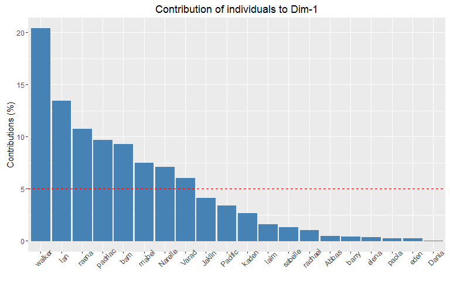

```r
fviz_pca_contrib(res.pca, choice = "ind", axes = 1)
```

**sur le 2ème axe:**

```r
rev(sort(round(res.pca$ind$contrib[,2],digits = 2)))
```

```
##    eden Pacific  Jaklin   paola   kaden   elena   barry sabelle rachael
##   21.18   10.08    9.81    9.79    8.86    7.01    6.95    6.67    6.05
##    laim   Dania   Varad  walker     bam   Abbas   raena padriac     Ian
##    5.26    2.03    1.65    1.52    1.44    0.96    0.39    0.18    0.15
##   mabel Narelle
##    0.02    0.00
```

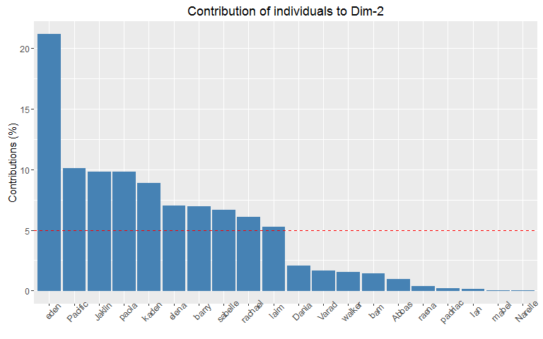

```r
fviz_pca_contrib(res.pca, choice = "ind", axes = 2)
```

# 9)-Représentation simultanée des patients et des variables

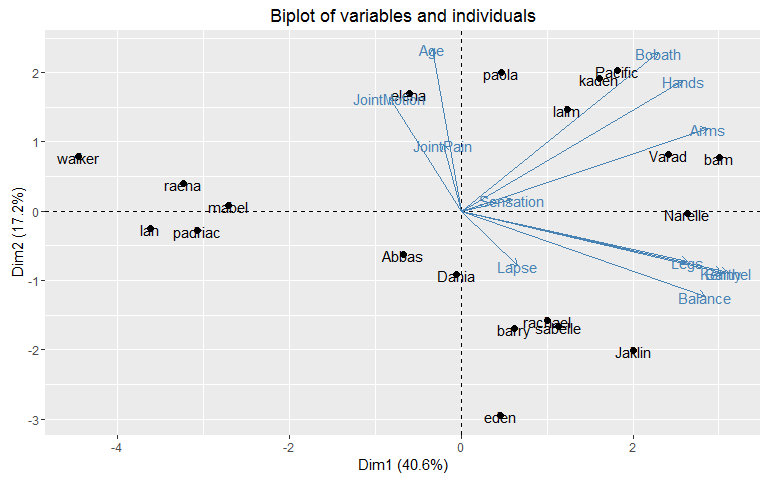

```r
fviz_pca_biplot(res.pca, geom=c("text","point"))+ theme_grey()
```

Ce biplot confirme ce qui est déja dit .

# Conclusion